# Find a two-dimensional penguin subspace

How can four body measurements be summarized in two coordinates? PCA answers this by finding a plane with small reconstruction error. The plane is a point on a Grassmann manifold: different orthonormal bases describe the same point. Here we optimize that plane directly and compare the result with `prcomp()`.

This builds on the sphere PCA introduction. For the geometry, see geometry and metrics and `manifold.grassmann()`.

## Data: four measurements, one common scale

The [Palmer Penguins data](https://allisonhorst.github.io/palmerpenguins/) were collected by Kristen Gorman and Palmer Station LTER. This site bundles the CC0 `penguins` data from `palmerpenguins` 0.1.1, so building this article requires no download. See data sources and reproducibility for attribution and the snapshot checksum.

```r
penguins <- read.csv("data/penguins.csv", stringsAsFactors = FALSE)
measurements <- c("bill_length_mm", "bill_depth_mm",
                  "flipper_length_mm", "body_mass_g")
complete <- complete.cases(penguins[, measurements])
X <- scale(as.matrix(penguins[complete, measurements]))
species <- factor(penguins$species[complete])
data.frame(total = nrow(penguins), retained = nrow(X),
           missing_measurements = sum(!complete))
```

```
#>   total retained missing_measurements
#> 1   344      342                    2
```

Bill and flipper measurements are in millimeters; mass is in grams. Centering and dividing each column by its sample standard deviation gives the four variables equal variance before optimization. Only missing body measurements cause row removal; missing sex values do not. Species labels color the final plot but are never inputs to the objective.

## Objective and geometry

Let *X* contain the standardized observations, and let *Q* be a $4 × 2$ matrix with orthonormal columns. We minimize

$$f(Q) = \frac{1}{2n}\|X-XQQ^\mathsf{T}\|_F^2.$$

Multiplying *Q* by any orthogonal $2 × 2$ matrix leaves its projector *Q**Q*<sup>T</sup>, and therefore the objective, unchanged. This is why we use `manifold.grassmann(4, 2)`.

```r
geometry <- manifold.grassmann(4, 2)
observations <- torch_tensor(X, dtype = torch_float64(), device = "cpu")
problem <- riem.problem(
  geometry,
  function(Q, data) {
    residual <- data - data$matmul(Q)$matmul(Q$t())
    (residual^2)$sum() / (2 * data$size(1))
  },
  data = observations
)
initial <- riem.random(geometry, device = "cpu", dtype = "float64")
```

Registering tensors through `data` lets the solver move them together with the point when the execution device changes. Automatic differentiation computes the ambient derivative, and the geometry supplies the tangent gradient.

## Solve and inspect termination

```r
fit <- riem.optimize(
  problem, initial, method = "conjugate_gradient",
  control = list(max_iterations = 200, gradient_tolerance = 1e-7),
  device = "cpu", dtype = "float64"
)
fit
```

```
#> <riem_fit> conjugate_gradient on grassmann
#>  Objective: 0.23617148  | gradient norm: 4.075e-08
#>  Termination: converged_gradient  | iterations: 38
```

```r
Q <- as.matrix(fit$point)
scores <- X %*% Q
```

`converged_gradient` means the metric gradient met the requested tolerance. `max_iterations` means the iteration allowance was exhausted, which alone does not establish convergence. Keep both the termination reason and gradient norm when comparing solvers.

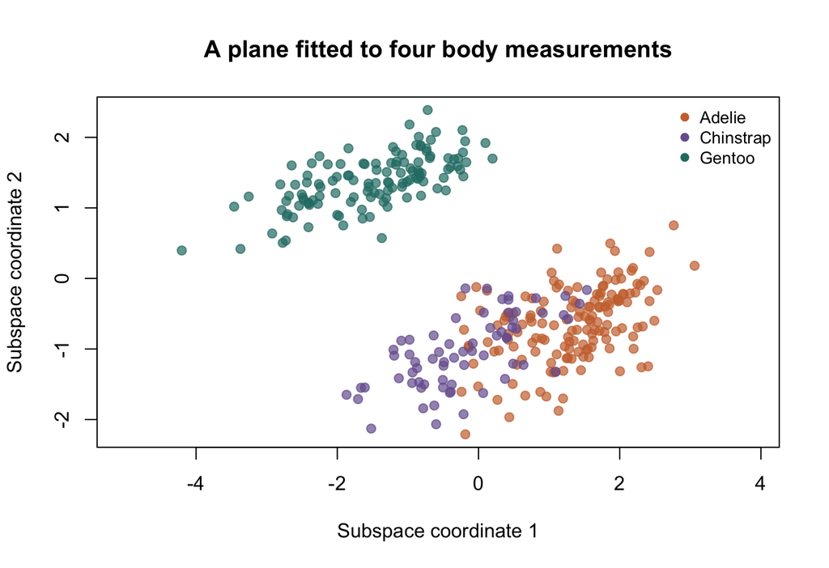

Species are used only to color the projection. The optimized basis can rotate without changing the plane.

The two displayed axes are coordinates in the fitted plane; they need not equal the ordered first and second principal-component axes. This is an exploratory representation, not a trained species classifier.

## A short finite-sum comparison

The same objective is the mean of one reconstruction loss per penguin. `riem.problem.finitesum()` can evaluate a selected minibatch in one tensor operation through `batch_fn`.

```r
finite_problem <- riem.problem.finitesum(
  geometry,
  function(Q, i, data) {
    observation <- data[i, ]
    residual <- observation - observation$matmul(Q)$matmul(Q$t())
    (residual^2)$sum() / 2
  },
  n = nrow(X),
  batch_fn = function(Q, indices, data) {
    batch <- data[indices, , drop = FALSE]
    residual <- batch - batch$matmul(Q)$matmul(Q$t())
    (residual^2)$sum(dim = 2) / 2
  },
  data = observations
)
torch_manual_seed(6102)
svrg_fit <- riem.optimize(
  finite_problem, initial, method = "svrg",
  control = list(max_iterations = 120, batch_size = 32, step_size = 0.15,
                 epoch_length = 20, full_evaluation_every = 20,
                 gradient_tolerance = 1e-7),
  device = "cpu", dtype = "float64"
)
fits <- list(conjugate_gradient = fit, svrg = svrg_fit)
data.frame(
  method = names(fits),
  objective = vapply(fits, function(x) x$objective, numeric(1)),
  full_gradient_norm = vapply(fits, function(x) x$gradient_norm, numeric(1)),
  termination = vapply(fits, function(x) x$termination, character(1))
)
```

```
#>                                method objective full_gradient_norm
#> conjugate_gradient conjugate_gradient 0.2361715       4.075100e-08
#> svrg                             svrg 0.2361729       1.173544e-03
#>                           termination
#> conjugate_gradient converged_gradient
#> svrg                   max_iterations
```

SVRG uses a full gradient at a snapshot plus transported minibatch corrections. The Grassmann frame representation supports the local logarithm needed to connect each snapshot to the current point. The small steps here stay within that local domain; the path is not defined at a Grassmann cut locus. Unsupported geometries or paths fail explicitly. See variance reduction and solver controls for the contract.

This deliberately short run is a demonstration, not a speed benchmark. Its final gradient is evaluated on all observations; the minibatch gradient does not certify stationarity. A small data matrix usually favors a deterministic method. More iterations or different steps may be needed for SVRG to satisfy the same stopping tolerance.

## Independent verification

Compare projectors, because comparing signed basis entries would penalize equivalent planes. `prcomp()` uses a separate singular-value decomposition. The fraction of standardized variance retained is ∥*X**Q*∥<sub>*F*</sub><sup>2</sup>/∥*X*∥<sub>*F*</sub><sup>2</sup>.

```r
reference <- prcomp(X, center = FALSE, scale. = FALSE)
reference_Q <- reference$rotation[, 1:2, drop = FALSE]
projector_error <- max(abs(tcrossprod(Q) - tcrossprod(reference_Q)))
captured <- sum(scores^2) / sum(X^2)
reference_captured <- sum(reference$sdev[1:2]^2) / sum(reference$sdev^2)

angle <- pi / 6
rotation <- matrix(c(cos(angle), sin(angle), -sin(angle), cos(angle)), 2, 2)
rotated_Q <- Q %*% rotation
rotation_error <- max(abs(tcrossprod(Q) - tcrossprod(rotated_Q)))
reconstruction_value <- function(basis) {
  sum((X - X %*% tcrossprod(basis))^2) / (2 * nrow(X))
}
finite_value <- as.numeric(riem.evaluate(finite_problem, fit$point,
                                        gradient = FALSE)$value)
initial_value <- as.numeric(riem.evaluate(problem, initial,
                                         gradient = FALSE)$value)
data.frame(
  projector_error, captured, reference_captured, rotation_error,
  svrg_objective_gap = svrg_fit$objective - fit$objective
)
```

```
#>   projector_error captured reference_captured rotation_error svrg_objective_gap
#> 1    4.492956e-08 0.881568           0.881568   1.110223e-16       1.382973e-06
```

```r
stopifnot(
  all(riem.belongs(geometry, fit$point)),
  projector_error < 1e-6,
  abs(captured - reference_captured) < 1e-10,
  rotation_error < 1e-12,
  abs(reconstruction_value(rotated_Q) - fit$objective) < 1e-10,
  abs(finite_value - fit$objective) < 1e-10,
  fit$gradient_norm < 1e-6,
  is.finite(svrg_fit$gradient_norm),
  svrg_fit$objective < initial_value
)
```

These tolerances check the plane, the objective normalization, and basis invariance separately. A second seeded execution should reproduce the reported numeric checks to absolute tolerance `1e-10` on the same CPU/runtime.

## Device selection and interpretation

This article explicitly uses CPU float64. In your own session, the same registered-data problem can select a suitable device automatically or honor an explicit override:

```r
riem.optimize(problem, initial, device = "auto", dtype = "float64")
riem.optimize(problem, initial, device = "cpu", dtype = "float64")
riem.optimize(problem, initial, device = "cuda:0", dtype = "float64")
```

The CUDA call requires an available compatible GPU. Results describe the complete observed measurements after standardization; different scaling or missing-data assumptions define a different analysis. The package supplies the optimization tools rather than a separate statistical PCA estimator.